# Lab 2

Team members:

- Matthew Benedict
- Gavin Bovone

## Business Understanding

The dataset we selected contains 1900 images of forests captured by drones, satellites, and on-the-ground cameras, labeled according to if a fire is present. The purpose of this dataset is to build a machine learning model that can identify whether a forest is actively experiencing a fire. The prediction task for this project is to classify forest images into two groups: fire present or no fire present. The motivation for this task is clear: early fire detection is extremely important as wildfire causes massive damage, economic loss, and dangers to people living in the area. According to the U.S. Forest Service, “we need to be prepared with highly trained people, well designed tools and high performing equipment to respond safely and effectively to forest and grassland fires”. Building an automated prediction model, in tandem with proper equipment and trained individuals, based on visual data can speed up the detection of fires making fire responses much faster. This would limit the losses caused by fires, making this project a valuable tool for preventing damage caused by fires.

## Measure of Success

Next, we need to determine what “success” looks like for this predictive model. Third parties who would be interested in these predictions include first responders and forestry management agencies. For first responders, the most important requirement is not missing actual fires as false negatives could delay action. For land managers, accuracy in distinguishing real fires from harmless conditions, like fog or clouds, is also important to reduce wasted resources from false alarms. Because stakeholders come from fields where people and resources need to be protected from danger, the required success rate must be very high. A research paper in Springer Open, “Wildfire assessment using machine learning algorithms in different regions,” discussed the efficacy of wildfire detection using similar algorithms. According to the paper, the models “showed an accuracy of over 75% in the correct classification of large fires” with the best model performing at an accuracy rate of over 90%. From this, we can find a reasonable success rate for our model: an overall accuracy of 75–90% would be ideal for this project to meet the minimum standards set by other models while still trying to limit mistakes as much as possible. A model performing within this range would be valuable as a support tool, helping interested parties decide which alerts need immediate attention.

## Citations

- https://fireecology.springeropen.com/articles/10.1186/s42408-024-00335-2
- https://www.fs.usda.gov/science-technology/managing-fire
- Dataset source: https://www.kaggle.com/datasets/brsdincer/wildfire-detection-image-data

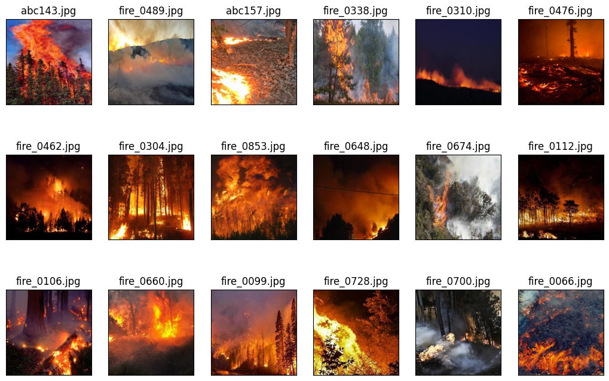

```python
# Data Preparation

from matplotlib.image import imread
from matplotlib import pyplot as plt
import numpy as np
import glob
import os

images = []
target = []
names = []

shape = (250, 250, 3)

# Use this definition instead if you don't want color
# You will get faster runtime in feature extraction but less explained variance from dropping color though unsurprisingly
# shape = (250, 250)

# Use this definition instead if you want only some images
#path = glob.iglob('forest_fire/Testing/**/*.jpg', recursive=True)

path = glob.iglob('forest_fire/**/*.jpg', recursive=True)

# Courtesy of https://stackoverflow.com/a/12201744
def rgb2gray(rgb):
    return np.dot(rgb[...,:3], [0.2989, 0.5870, 0.1140])

done = False
for image_path in path:
    # Read in image
    img = imread(image_path)

    # Transform image
    if len(shape) < 3: img = rgb2gray(img)
    flat_img = img.flatten()
    images.append(flat_img)
    # Target is true if the image has a fire and false if it does not
    target.append("nofire" not in image_path)
    # Get name
    names.append(os.path.basename(os.path.normpath(image_path)))

# Visualize some images
def plot_gallery(images, titles, n_row=3, n_col=6):
    """Helper function to plot a gallery of portraits"""
    plt.figure(figsize=(1.7 * n_col, 2.3 * n_row))
    plt.subplots_adjust(bottom=0, left=.01, right=.99, top=.90, hspace=.35)
    for i in range(n_row * n_col):
        plt.subplot(n_row, n_col, i + 1)
        if len(shape) < 3:
            plt.imshow(images[i].reshape(shape), cmap=plt.cm.gray)
        else:
            plt.imshow(images[i].reshape(shape))
        plt.title(titles[i], size=12)
        plt.xticks(())
        plt.yticks(())

# Image data are assumed to be floats from now on so they need to be scaled
X = np.array(images) / 255.0

plot_gallery(X, names)
```

We first read all of the images in the forest_fire directory where each picture is classified as fire or no fire (fire in the picture or not). Each picture was already $250 \times 250$ pixels and our computers were able to handle all of the following code without too much trouble, so we decided not to resize the images. We also created the greyscale option for the images for the daisy analysis later, but we are going to keep the pictures colored. The function `img.flatten()` linearizes the images to create a table of 1-D image features. For output purposes, these images are unflattened back to their original dimension of $250 \times 250$ and 3 color channels to show some sample images using `plot_gallery`.

```python
# Let's do some PCA of the features and go from 187,500 features to 300 features
from sklearn.decomposition import PCA

n_components = 300
print ("Extracting the top %d eigenforests from %d forests" % (
    n_components, X.shape[0]))

pca = PCA(n_components=n_components)
%time pca.fit(X.copy())
eigenforests = pca.components_.reshape((n_components, *shape))
```

```
Extracting the top 300 eigenforests from 1900 forests
CPU times: user 24.3 s, sys: 6.83 s, total: 31.1 s
Wall time: 28.2 s
```

```
-0.012516059718658297 0.013831847781107801
```

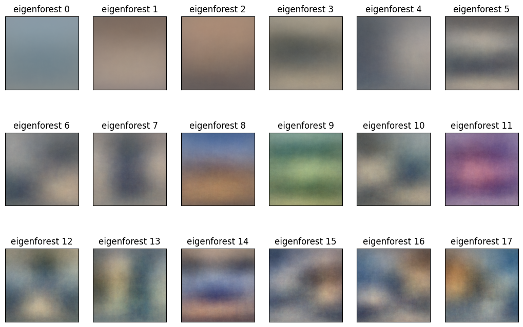

```python
# Output our eigenforests just to see what they look like
eigenforest_titles = ["eigenforest %d" % i for i in range(eigenforests.shape[0])]
# Note: The range of these eigenforests
_min = np.min(eigenforests)
_max = np.max(eigenforests)
print(_min, _max)
eigenforests_normalized = (eigenforests - _min) / (_max - _min)
plot_gallery(eigenforests_normalized, eigenforest_titles)
```

```python
def plot_explained_variance(pca):
    import plotly
    from plotly.graph_objs import Bar, Line
    from plotly.graph_objs import Scatter, Layout
    from plotly.graph_objs.scatter import Marker
    from plotly.graph_objs.layout import XAxis, YAxis
    plotly.offline.init_notebook_mode() # run at the start of every notebook

    explained_var = pca.explained_variance_ratio_
    cum_var_exp = np.cumsum(explained_var)

    plotly.offline.iplot({
        "data": [Bar(y=explained_var, name='individual explained variance'),
                 Scatter(y=cum_var_exp, name='cumulative explained variance')
            ],
        "layout": Layout(xaxis=XAxis(title='Principal components'), yaxis=YAxis(title='Explained variance ratio'))
    })

plot_explained_variance(pca)

# We get 85% variance explained by reducing to ~150 components!
```

[interactive chart not shown]

Here, we found the explained variance for each individual eigenvector, and then the cumulative explained variance and graphed it. By analyzing the explained variance ratios, we found that the first ~ 150 eigenfaces capture approximately 85% of the total variance. After the first 150 components the explained variance seems to plateau and not much is really gained by keeping any more features.

```python
n_components = 300
print("Extracting the top %d eigenforests from %d forests" %
      (n_components, X.shape[0]))

rpca = PCA(n_components=n_components, svd_solver='randomized')
%time rpca.fit(X.copy())
eigenforests_rpca = rpca.components_.reshape((n_components, *shape))
```

```
Extracting the top 300 eigenforests from 1900 forests
CPU times: user 24.3 s, sys: 7.72 s, total: 32.1 s
Wall time: 30.6 s
```

```python
plot_explained_variance(rpca)

# We also get 85% variance explained with ~150 components! The performance is about the same!
```

[interactive chart not shown]

Here, we performed a random PCA on the data. The graph of the explained variance ratio looks pretty much identical to the one from the standard PCA with around 150 of the components accounting for 85% of the variance. Because both types of PCA had extremely similar results, we believe that only 150 dimensions are required to accurately represent the data. We still need to analyze the differences in the PCA and the random one to determine which is the better option, which we do later on in this project after we perform feature extraction using DAISY.

```python
from skimage.feature import daisy
features = daisy(rgb2gray(img), step=10, radius=20, rings=2, histograms=8, orientations=4, visualize=False)
print(features.shape)
print(features.shape[0]*features.shape[1]*features.shape[2])
```

```
(21, 21, 68)
29988
```

```python
def apply_daisy(row,shape):
    if len(shape) < 3:
        gray_img = row.reshape(shape)
    else:
        gray_img = rgb2gray(row.reshape(shape))
    feat = daisy(gray_img, step=10, radius=20,
                 rings=2, histograms=8, orientations=4,
                 visualize=False)
    return feat.reshape((-1))

%time test_feature = apply_daisy(X[3], shape)
print(test_feature.shape)

# This is going to take a long time, e.g. 42.7 ms * 1900 images = 58.2 seconds
%time daisy_features = np.apply_along_axis(apply_daisy, 1, X, shape)
print(daisy_features.shape)
```

```
CPU times: user 30.8 ms, sys: 4.5 ms, total: 35.3 ms
Wall time: 36.8 ms
(29988,)
CPU times: user 56 s, sys: 4.81 s, total: 1min
Wall time: 1min 1s
(1900, 29988)
```

Here we apply DAISY to our images to see if converting our data into DAISY features can yield useful information. Note for comparison that while relatively high dimensionality of DAISY features nearing 30,000 features for just one image is still much smaller than our image size of 187,500 features ($250 \times 250 \times 3$), it is orders of magnitude larger than the necessary features for PCA.

```python
# Magic number to keep 85% of variance
n_components = 152

pca = PCA(n_components=n_components)
%time X_pca_features = pca.fit_transform(X)

rpca = PCA(n_components=n_components, svd_solver='randomized')
%time X_rpca_features = rpca.fit_transform(X)
y = np.array(target)

from sklearn.neighbors import KNeighborsClassifier
from sklearn.metrics import accuracy_score
from sklearn.model_selection import train_test_split

# init a classifier for each feature space
knn_pca = KNeighborsClassifier(n_neighbors=1)
knn_rpca = KNeighborsClassifier(n_neighbors=1)
knn_dsy = KNeighborsClassifier(n_neighbors=1)

# separate the data into train/test
pca_train, pca_test, rpca_train, rpca_test, dsy_train, dsy_test, y_train, y_test = \
    train_test_split(X_pca_features, X_rpca_features, daisy_features, y, test_size=0.2, train_size=0.8)

# fit each classifier
knn_pca.fit(pca_train,y_train)
acc_pca = accuracy_score(knn_pca.predict(pca_test),y_test)

knn_rpca.fit(rpca_train,y_train)
acc_rpca = accuracy_score(knn_rpca.predict(rpca_test),y_test)

knn_dsy.fit(dsy_train,y_train)
acc_dsy = accuracy_score(knn_dsy.predict(dsy_test),y_test)

# report accuracy
print(f"PCA accuracy: {100*acc_pca:.2f}%\nRPCA accuracy: {100*acc_rpca:.2f}%\nDaisy Accuracy: {100*acc_dsy:.2f}%".format())
```

```
CPU times: user 18.2 s, sys: 2.46 s, total: 20.6 s
Wall time: 17 s
CPU times: user 18 s, sys: 3.1 s, total: 21.1 s
Wall time: 17.1 s
PCA accuracy: 83.16%
RPCA accuracy: 82.89%
Daisy Accuracy: 64.47%
```

Here, we built a nearest neighbor classifier to test the accuracy of DAISY, the PCA, and the random PCA. DAISY performed the worst out of the three with an accuracy of ~65%, and both the PCA and the random versions having an accuracy of ~83%. Due to random variation in the selection of training and test data, the difference between randomized and non-randomized PCA in terms of accuracy is statistically insignificant. This is a surpisingly low accuracy for the DAISY feature extraction, although it may be partially due to applying greyscale to the images before implementing it as is required. However, a major difference between images of forests with and without fires is in the red color of the fire, so removing that from the images made it much harder to discern the differences between forests with and without fires. Now for deciding which PCA to use: since both the explained variance ratio and accuracy results of the two methods were insignificant, we decided to choose the method that took less time to run, which in our case, was the normal PCA. It could very well be the case that as the dataset increases in size, randomized PCA could result in significant time savings and would be the better choice.

In conclusion, the DAISY image feature extraction did not show very much promise for our project compared to a PCA baseline. While a major limitation in our conclusion is that fine-tuning hyperparameters in DAISY could lead to different results, there is already nearly 200 times overhead in terms of dimensionality (152 features for PCA vs. 29,988 features for DAISY) for it to be unable to compete with PCA. Furthermore, PCA meets our initially defined measure of success, with our results consistently in excess of 80% and thus within the bounds of established literature for this classification task.